# Barvy

Author

MD

Published

March 24, 2026

```r
# install instructions for RLing
#
# - [ ] install devtools
# - [ ] gunzip Rling_1.0.tar.gz
# - [ ] devtools::install_local("Rling_1.0.tar")
# - [ ] also works: install.packages(pkgs = file.choose(), repos = NULL, type = "source")

library(Rling)
#library(languageR)

# English 'black'

data(colreg)

colreg
```

```
       spoken fiction academic press
black   20335   41118    26892 73080
blue     4693   22093     3605 21210
brown    1185   10914     1201 11539
gray     1168   12140     1289  6559
green    3860   14398     4477 26837
orange    931    3496      474  5766
pink      962    7312      584  6356
purple    613    3366      429  3403
red      7230   25111     5621 34596
white   14474   40745    26336 54883
yellow   1349   10553     1855 10382
```

# Stará debata

- univerzální hierarchie barev: Berlin and Kay (1991)
- Universality And Evolution of Basic Color Terms
- [WALS](https://wals.info/chapter/132)

# Derivační morfologie?

- Levshina: základní nápad – Deviation of Proportions, DP (Gries 2008; Lijijt & Gries 2012)
- více lingvistický přístup?
- intuice:

. . Na obzoru se černaly mraky. Na obzoru se ??oranžovělo slunce.

. . Petr nabílil košili. Petr ??naoranžověl košili.

. . Petr začernil text. Petr ??zaokroval text.

- DeriNET search: [pos=“A” lemma=“bílý”] [pos=“V”]
- vs. [pos=“A” lemma=“okrový”] [pos=“V”]
- [DeriNET](https://ufal.mff.cuni.cz/derinet/derinet-search) – v1

# Korpusy

- [ČNK-search](https://www.korpus.cz/slovo-v-kostce/search/cs/b%C3%ADl%C3%BD?lemma=&pos=)
- [COCA-search](https://www.wordfrequency.info/)
- back to Levshina:
- freqreq: sizes of 4 COCA registers

```r
freqreg <- c(95385672, 90344134, 91044778, 187245672)

freqreg
```

```
[1]  95385672  90344134  91044778 187245672
```

```r
exp_prop <- prop.table(freqreg)

exp_prop
```

```
[1] 0.2055636 0.1946987 0.1962086 0.4035291
```

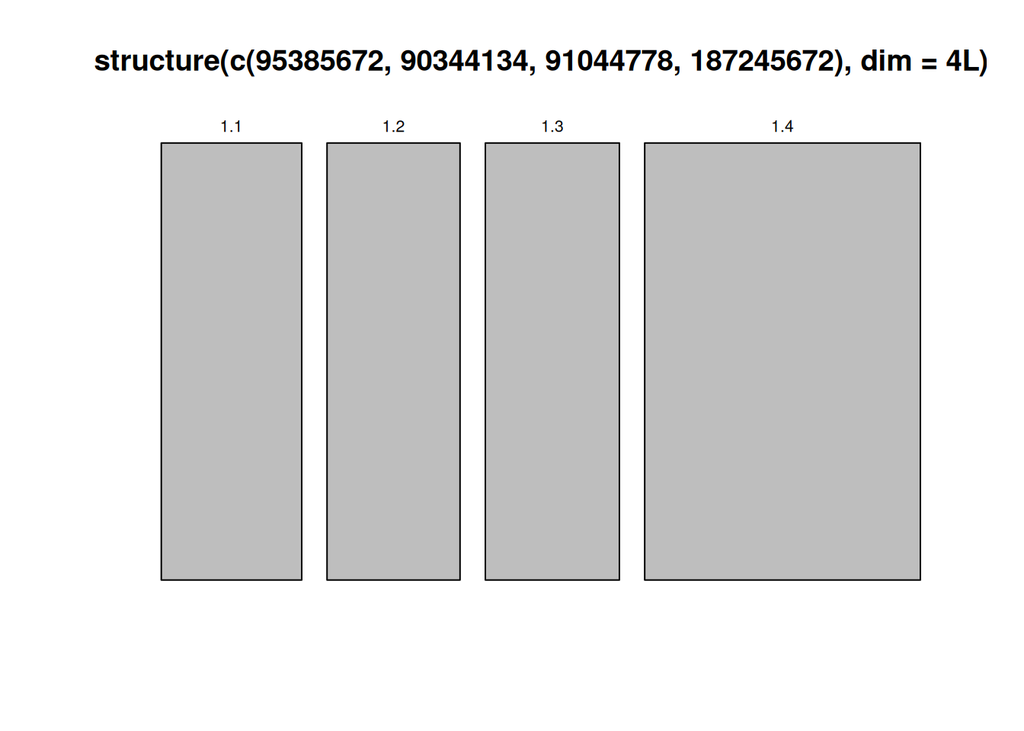

```r
mosaicplot(freqreg)
```

```r
colreg[1,]
```

```
      spoken fiction academic press
black  20335   41118    26892 73080
```

```r
black_obs <- prop.table(colreg[1,])

black_obs
```

```
         spoken   fiction  academic    press
black 0.1259718 0.2547189 0.1665913 0.452718
```

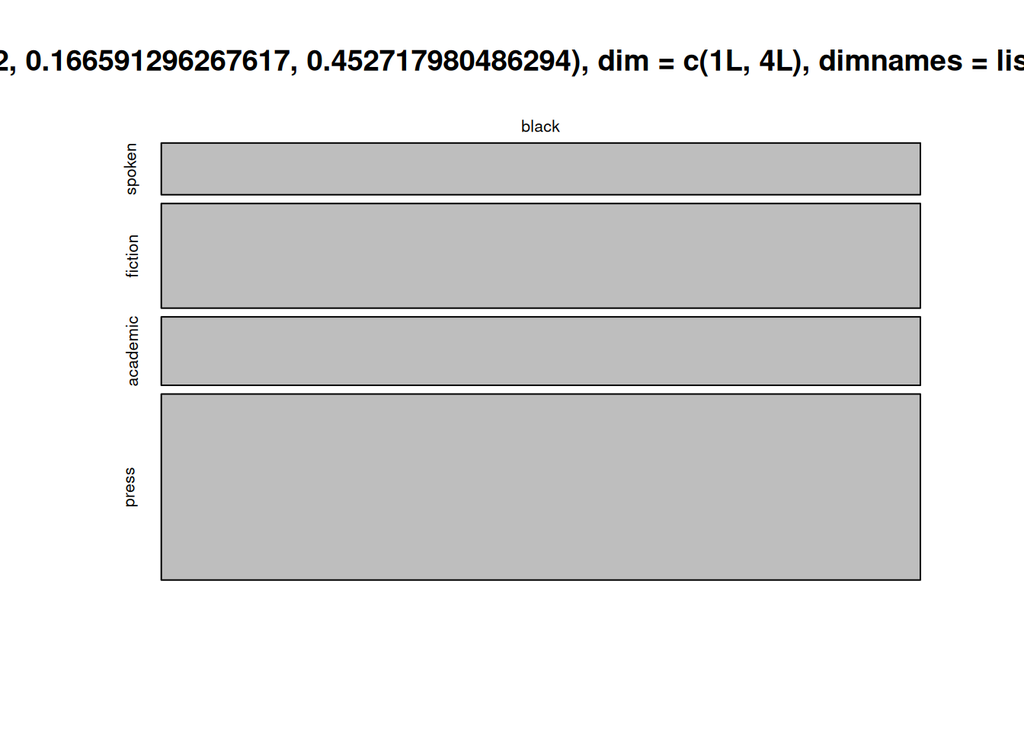

```r
mosaicplot(black_obs)
```

```r
DP_black <- sum(abs(black_obs - exp_prop))/2

DP_black
```

```
[1] 0.1092091
```

```r
min(exp_prop)
```

```
[1] 0.1946987
```

```r
DP_black_norm <- DP_black/(1 - min(exp_prop))

DP_black_norm
```

```
[1] 0.1356127
```

# English “gray”

```r
gray_obs <- prop.table(colreg[4,])

gray_obs
```

```
         spoken   fiction   academic     press
gray 0.05520892 0.5738325 0.06092834 0.3100303
```

```r
DP_gray <- sum(abs(gray_obs - exp_prop))/2

DP_gray
```

```
[1] 0.3791338
```

```r
DP_gray_norm <- DP_gray/(1 - min(exp_prop))

DP_gray_norm
```

```
[1] 0.4707974
```

# Czech “černý”

```r
cerny_obs <- c(363,181,175,124)

cerny_obs
```

```
[1] 363 181 175 124
```

```r
freq_cz_reg <- c(1000000,1000000,1000000,1000000)

exp_cz_prop <- prop.table(freq_cz_reg)

exp_cz_prop
```

```
[1] 0.25 0.25 0.25 0.25
```

```r
cerny_obs <- prop.table(cerny_obs)

cerny_obs
```

```
[1] 0.4306050 0.2147094 0.2075919 0.1470937
```

```r
DP_cerny <- sum(abs(cerny_obs - exp_cz_prop))/2

DP_cerny
```

```
[1] 0.180605
```

```r
DP_cerny_norm <- DP_cerny/(1 - min(exp_cz_prop))

DP_cerny_norm
```

```
[1] 0.2408066
```

```r
DP_black_norm
```

```
[1] 0.1356127
```

# Czech “okrová”

```r
okrovy_obs <- c(0,4,2,1)

okrovy_obs
```

```
[1] 0 4 2 1
```

```r
freq_cz_reg <- c(1000000,1000000,1000000,1000000)

exp_cz_prop <- prop.table(freq_cz_reg)

exp_cz_prop
```

```
[1] 0.25 0.25 0.25 0.25
```

```r
okrovy_obs <- prop.table(okrovy_obs)

okrovy_obs
```

```
[1] 0.0000000 0.5714286 0.2857143 0.1428571
```

```r
DP_okrovy <- sum(abs(okrovy_obs - exp_cz_prop))/2

DP_okrovy
```

```
[1] 0.3571429
```

```r
DP_okrovy_norm <- DP_okrovy/(1 - min(exp_cz_prop))

DP_okrovy_norm
```

```
[1] 0.4761905
```

```r
DP_black_norm
```

```
[1] 0.1356127
```

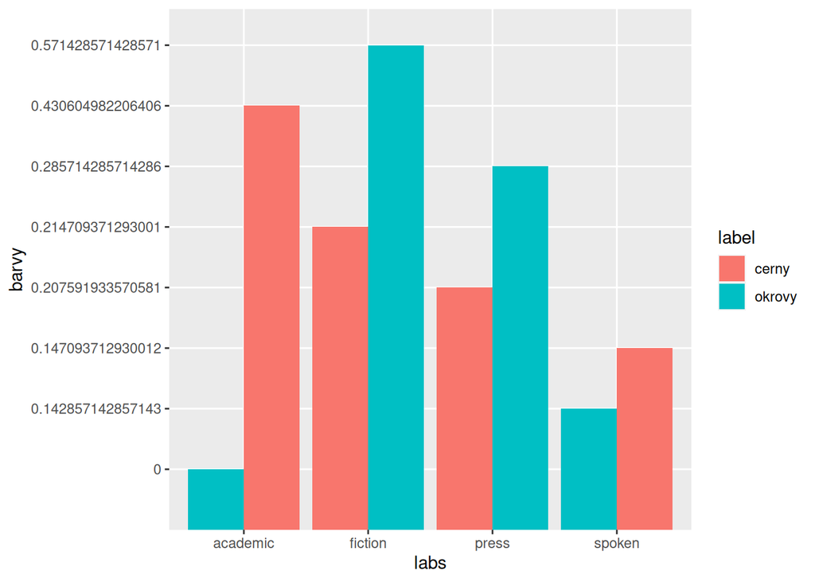

```r
library(ggplot2)

labs <- c("academic","fiction","press","spoken")

label <- rep(c("okrovy","cerny"), each =4)

barvy <- c(okrovy_obs,cerny_obs)

df <- cbind(labs,barvy,label)
df <- as.data.frame(df)

ggplot(data=df, aes(x=labs, y=barvy, fill=label)) +
geom_bar(stat="identity", position=position_dodge())
```

# Czech “oranžový”

```r
oranzovy_obs <- c(23,22,16,25)

oranzovy_obs
```

```
[1] 23 22 16 25
```

```r
freq_cz_reg <- c(1000000,1000000,1000000,1000000)

exp_cz_prop <- prop.table(freq_cz_reg)

exp_cz_prop
```

```
[1] 0.25 0.25 0.25 0.25
```

```r
oranzovy_obs <- prop.table(oranzovy_obs)

oranzovy_obs
```

```
[1] 0.2674419 0.2558140 0.1860465 0.2906977
```

```r
DP_oranzovy <- sum(abs(oranzovy_obs - exp_cz_prop))/2

DP_oranzovy
```

```
[1] 0.06395349
```

```r
DP_oranzovy_norm <- DP_oranzovy/(1 - min(exp_cz_prop))

DP_oranzovy_norm
```

```
[1] 0.08527132
```

```r
DP_black_norm
```

```
[1] 0.1356127
```

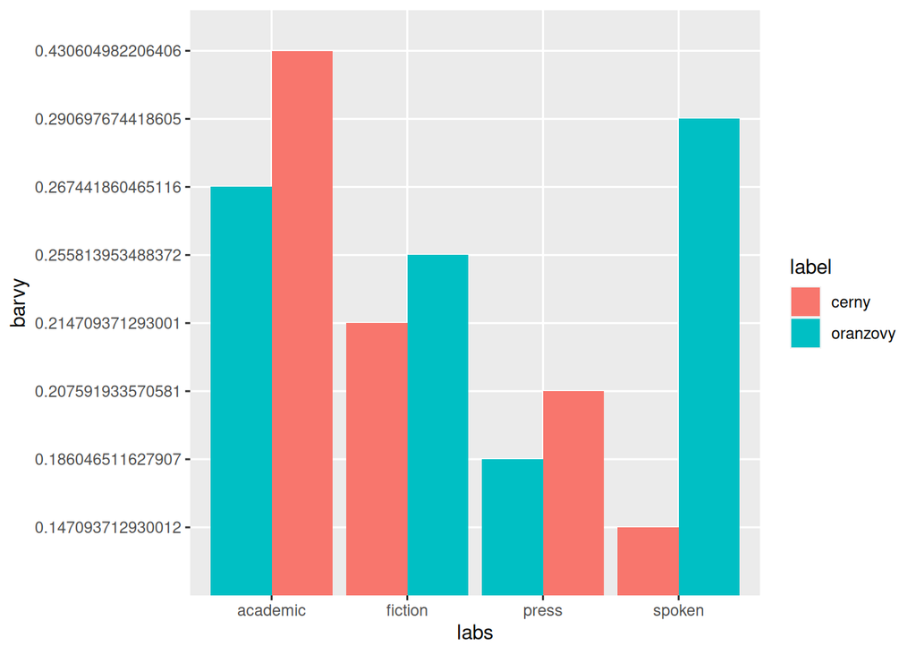

```r
library(ggplot2)

labs <- c("academic","fiction","press","spoken")

label <- rep(c("oranzovy","cerny"), each =4)

barvy <- c(oranzovy_obs,cerny_obs)

df <- cbind(labs,barvy,label)
df <- as.data.frame(df)

ggplot(data=df, aes(x=labs, y=barvy, fill=label)) +
geom_bar(stat="identity", position=position_dodge())
```

# back to English

```r
primcol <- colreg[c(1, 2, 5, 9:11),]

primcol
```

```
       spoken fiction academic press
black   20335   41118    26892 73080
blue     4693   22093     3605 21210
green    3860   14398     4477 26837
red      7230   25111     5621 34596
white   14474   40745    26336 54883
yellow   1349   10553     1855 10382
```

```r
seccol <- colreg[-c(1, 2, 5, 9:11),]

seccol
```

```
       spoken fiction academic press
brown    1185   10914     1201 11539
gray     1168   12140     1289  6559
orange    931    3496      474  5766
pink      962    7312      584  6356
purple    613    3366      429  3403
```

```r
primcol_sums <- colSums(primcol)

primcol_sums
```

```
  spoken  fiction academic    press
   51941   154018    68786   220988
```

```r
seccol_sums <- colSums(seccol)

seccol_sums
```

```
  spoken  fiction academic    press
    4859    37228     3977    33623
```

```r
primcol_obs <- prop.table(primcol_sums)

primcol_obs
```

```
   spoken   fiction  academic     press
0.1047762 0.3106874 0.1387561 0.4457803
```

```r
seccol_obs <- prop.table(seccol_sums)

seccol_obs
```

```
    spoken    fiction   academic      press
0.06097607 0.46717783 0.04990776 0.42193833
```

```r
DP_primcol <- sum(abs(primcol_obs - exp_prop))/2

DP_primcol
```

```
[1] 0.1582399
```

```r
DP_seccol <- sum(abs(seccol_obs - exp_prop))/2

DP_seccol
```

```
[1] 0.2908884
```

```r
DP_primcol_norm <- DP_primcol/(1 - min(exp_prop))

DP_primcol_norm
```

```
[1] 0.1964978
```

```r
DP_seccol_norm <- DP_seccol/(1 - min(exp_prop))

DP_seccol_norm
```

```
[1] 0.3612168
```

### Trying some standard tools

- first idea: chi-square test, baseline from freqreq
- let’s check but in simple cases chisq.test should work:

```r
x <- c(1000, 2000, 2000, 1000)
y <- c(99, 201, 201, 99)

table_test <- matrix(c(x, y), nrow = 2, byrow = TRUE)

print(table_test)
```

```
     [,1] [,2] [,3] [,4]
[1,] 1000 2000 2000 1000
[2,]   99  201  201   99
```

```r
chisq.test(table_test)
```

```
    Pearson's Chi-squared test

data:  table_test
X-squared = 0.027285, df = 3, p-value = 0.9988
```

```r
# more varied y

y <- c(10, 10, 201, 50)
table_test <- matrix(c(x, y), nrow = 2, byrow = TRUE)

print(table_test)
```

```
     [,1] [,2] [,3] [,4]
[1,] 1000 2000 2000 1000
[2,]   10   10  201   50
```

```r
chisq.test(table_test)
```

```
    Pearson's Chi-squared test

data:  table_test
X-squared = 221.88, df = 3, p-value < 2.2e-16
```

- now to data

```r
table_test_prim <- matrix(c(freqreg, primcol_sums), nrow = 2, byrow = TRUE)

print(table_test_prim)
```

```
         [,1]     [,2]     [,3]      [,4]
[1,] 95385672 90344134 91044778 187245672
[2,]    51941   154018    68786    220988
```

```r
chisq.test(table_test_prim)
```

```
    Pearson's Chi-squared test

data:  table_test_prim
X-squared = 69204, df = 3, p-value < 2.2e-16
```

```r
# fisher's test doesn't work

table_test_sec <- matrix(c(freqreg, seccol_sums), nrow = 2, byrow = TRUE)

print(table_test_sec)
```

```
         [,1]     [,2]     [,3]      [,4]
[1,] 95385672 90344134 91044778 187245672
[2,]     4859    37228     3977     33623
```

```r
chisq.test(table_test_sec)
```

```
    Pearson's Chi-squared test

data:  table_test_sec
X-squared = 47238, df = 3, p-value < 2.2e-16
```

```r
# that's why they probably don't use standard tests
```

- another possibility: proportions
- slightly better at first sight but there’s a problem: chisq.test should be used for count data, not fractions
- moreover the result is very tiny variation

```r
table_test_prim <- matrix(c(prop.table(freqreg), prop.table(primcol_sums)), nrow = 2, byrow = TRUE)

print(table_test_prim)
```

```
          [,1]      [,2]      [,3]      [,4]
[1,] 0.2055636 0.1946987 0.1962086 0.4035291
[2,] 0.1047762 0.3106874 0.1387561 0.4457803
```

```r
chisq.test(table_test_prim)
```

```
    Pearson's Chi-squared test

data:  table_test_prim
X-squared = 0.071308, df = 3, p-value = 0.995
```

```r
table_test_sec <- matrix(c(prop.table(freqreg), prop.table(seccol_sums)), nrow = 2, byrow = TRUE)

print(table_test_sec)
```

```
           [,1]      [,2]       [,3]      [,4]
[1,] 0.20556360 0.1946987 0.19620863 0.4035291
[2,] 0.06097607 0.4671778 0.04990776 0.4219383
```

```r
chisq.test(table_test_sec)
```

```
    Pearson's Chi-squared test

data:  table_test_sec
X-squared = 0.27798, df = 3, p-value = 0.9641
```

# CQL Query Construction for Czech Corpus Analysis

## Research Question

Investigating the distribution of indefinite pronouns (“jakýkoliv” vs. “sebemenší”) in contexts with the Czech modal verb “moct” (can/may).

**Hypothesis:** “Jakýkoliv” appears freely with modal verbs like “moct”, while “sebemenší” (a negative polarity item) requires licensing by negation or prepositions like “bez”.

## CQL Queries for SketchEngine (csTenTen corpus)

### Basic Query for “moct” + “jakýkoliv”

```
[lemma="moct"] []{0,5} [lemma="jakýkoliv"] within <s/>
```

**Result:** 101,309 hits

### Basic Query for “moct” + “sebemenší”

```
[lemma="moct"] []{0,5} [lemma="sebemenší"] within <s/>
```

**Result:** 2,505 hits

### Corpus Totals

```
[lemma="jakýkoliv"]
```

**Total:** 1,639,875

```
[lemma="sebemenší"]
```

**Total:** 120,944

## Statistical Analysis

### 2×2 Contingency Table

|  | **moct context** | **non-moct context** | **Total** |
| --- | --- | --- | --- |
| **jakýkoliv** | 101,309 | 1,538,566 | 1,639,875 |
| **sebemenší** | 2,505 | 118,439 | 120,944 |

### Fisher’s Exact Test (R)

```r
fisher.test(matrix(c(101309, 1538566, 2505, 118439), nrow=2))
```

### Results

| Statistic | Value |
| --- | --- |
| **p-value** | < 2.2e-16 |
| **Odds ratio** | 3.11 |
| **95% CI** | [2.99, 3.24] |

### Interpretation

- **p < 0.001**: The association is highly statistically significant
- **OR = 3.11**: “Jakýkoliv” is about **3 times more likely** to appear in `moct` contexts than “sebemenší”
- The confidence interval doesn’t include 1, confirming the effect is robust

## Domácí úloha

- kombinace primárních a sekundárních barev

```r
primarni_barvy <- c("černá", "modrá", "zelená", "červená", "bílá", "žlutá")
sekundární_barvy <- c("hnědá", "šedá", "oranžová", "růžová", "fialová")

# let's make all possible pairs of primary and secondary colors

kombinace <- expand.grid(primarni_barvy, sekundární_barvy)
print(kombinace)
```

```
      Var1     Var2
1    černá    hnědá
2    modrá    hnědá
3   zelená    hnědá
4  červená    hnědá
5     bílá    hnědá
6    žlutá    hnědá
7    černá     šedá
8    modrá     šedá
9   zelená     šedá
10 červená     šedá
11    bílá     šedá
12   žlutá     šedá
13   černá oranžová
14   modrá oranžová
```

[output cut: 16 more lines]

```r
# add name of student as third row and save it as csv

kombinace <- cbind(kombinace, "name" = "name")

write.csv(kombinace, "zadani_barev.csv")
```

## References

Berlin, Brent, and Paul Kay. 1991. *Basic Color Terms: Their Universality and Evolution*. Univ of California Press.